# Tarea 1. Programa en R

Diana Laura Javier Garcia

9/9/2020

El objetivo de esta tarea es analizar los parámetros estadísticos de un grupo de datos ordenados en los campos, o variables, consumo, cilindrada (CC), potencia (CV), peso y aceleración.

El código en R comienza con la lectura de los datos.

```r
autos<-read.table("autos.txt",header = T)
attach(autos)
```

# Parámetros estadísticos de la variable aceleración

Para obtener el histograma se emplea el siguiente código:

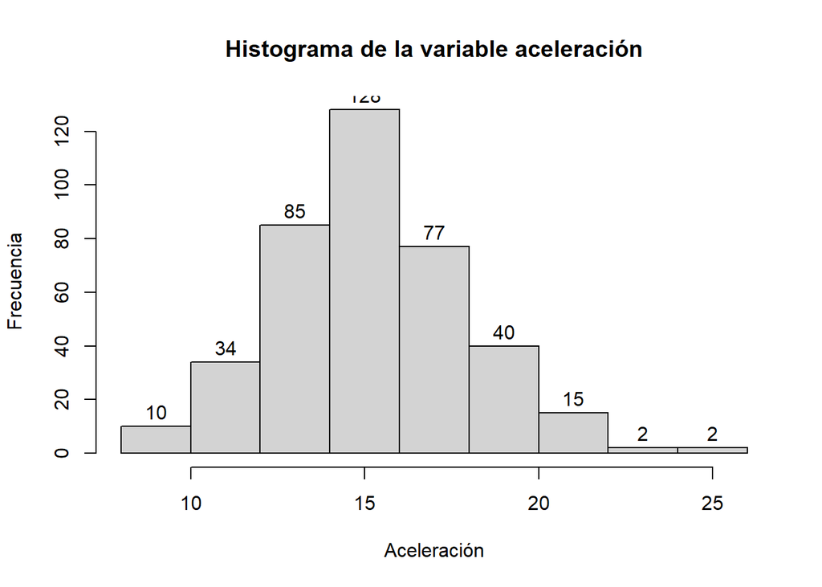

```r
hist(Acel, main = "Histograma de la variable aceleración", ylab = "Frecuencia", xlab = "Aceleración", labels = TRUE)
```

Mientras que para obtener el diagrama de caja se empleó la instrucción:

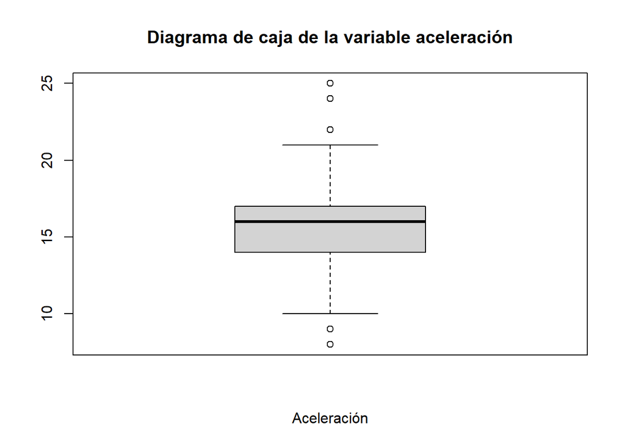

```r
boxplot(Acel, main ="Diagrama de caja de la variable aceleración", xlab = "Aceleración", labels = TRUE)
```

Además, el programa nos permite conocer el resumen de los parámetros estadísticos con el siguiente código.

```r
summary(Acel)
```

```
##    Min. 1st Qu.  Median    Mean 3rd Qu.    Max.
##    8.00   14.00   16.00   15.67   17.00   25.00
```

# Parámetros estadísticos de la variable peso

En esta sección se muestra el histograma de la variable peso, el cual se obtuvo con la siguiente instrucción:

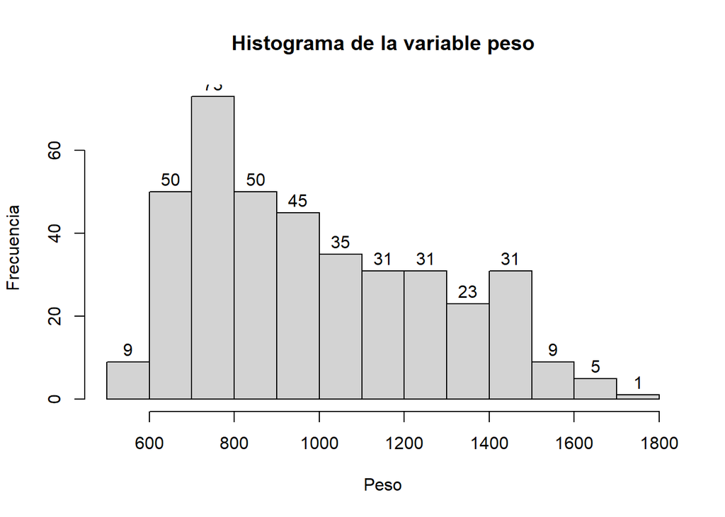

```r
hist(Peso, main = "Histograma de la variable peso", ylab = "Frecuencia", xlab = "Peso", labels = TRUE)
```

Por otra parte, se muestra el diagrama de caja de la variable peso, el cual se obtuvo con la siguiente instrucción:

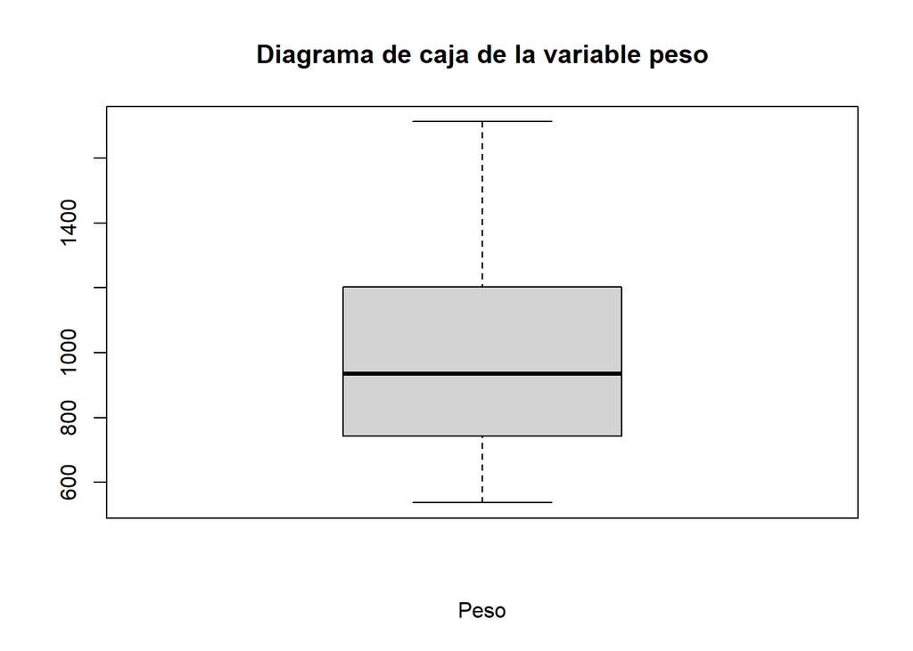

```r
boxplot(Peso, main = "Diagrama de caja de la variable peso", xlab = "Peso", labels = TRUE)
```

Además, el programa nos permite conocer el resumen de los parámetros estadísticos con el siguiente código.

```r
summary(Peso)
```

```
##    Min. 1st Qu.  Median    Mean 3rd Qu.    Max.
##   537.0   742.0   935.0   990.6  1203.0  1713.0
```

Finalmente, se muestra el resumen de todas las variables:

```r
summary(autos)
```

```
##    ï..Consumo          CC             CV             Peso
##  Min.   : 5.00   Min.   :1114   Min.   : 46.0   Min.   : 537.0
##  1st Qu.: 8.00   1st Qu.:1721   1st Qu.: 75.0   1st Qu.: 742.0
##  Median :10.00   Median :2474   Median : 93.0   Median : 935.0
##  Mean   :11.22   Mean   :3179   Mean   :104.2   Mean   : 990.6
##  3rd Qu.:13.00   3rd Qu.:4293   3rd Qu.:125.0   3rd Qu.:1203.0
##  Max.   :24.00   Max.   :7456   Max.   :230.0   Max.   :1713.0
##                                 NA's   :2
##       Acel
##  Min.   : 8.00
##  1st Qu.:14.00
##  Median :16.00
##  Mean   :15.67
##  3rd Qu.:17.00
##  Max.   :25.00
##
```

# Análisis de resultados

En la sección anterior se presentó el histograma y el diagrama de caja de las variables aceleración y peso. Con base en ello y en el resumen de datos se realizan las siguientes observaciones:

Aceleración:

1.- La aceleración tiene un promedio de $15.67\frac{km}{s}$.

2.- El primer y tercer cuartil tienen valores de 14 y 17, por lo tanto la diferencias de estos (conocido como rango intercuartílico) permite mostrar que los datos no presentan una dispersión importante.

4.- El primer cuartil indica que el primer $25\%$ de los datos se encuentran entre 8 y 14. Mientras que el $50\%$ de los datos se encuentran entre el valor mínimo de 8 y la mediana con valor de 16. Asimismo, el tercer cuartil que separa al $75\%$ de los datos ordenados de mayor a menor se encuentran entre 8 y 17.

5.- El histograma de la variable aceleración tiene una moda, con una distribución simétrica, es decir, presenta una distribución normal.

Peso

1.- Con base en los resultados presentados, se encontró que el peso promedio de los autos estudiados es de 990.6 kg.

2.- A partir del diagrama de caja se observa que existe una dispersión importante en los datos, sobre todo si se considera que el valor máximo (1713.0) se encuentra alejado de la mediana (935).

3.- El primer cuartil indica que el primer $25\%$ de los datos se encuentran entre 537.0 y 742.0. Mientras que el $50\%$ de los datos se encuentran entre el valor mínimo de 537.0 y la mediana con valor de 935.0. Asimismo, el tercer cuartil que separa al $75\%$ de los datos ordenados de mayor a menor se encuentran entre 537 y 1203.0.

4.- Con respecto a la distribución de los datos por frencuencias, se observa que los datos con mayor frencuencia se encuentran entre 600 y 1000, donde el intervalo entre 700 y 800 presenta la mayor frencuencia.

# Conclusiones

En este trabajo se lograron los objetivos establecidos. El programa R permitió realizar un análisis estadístico de los datos de aceleración y peso de varios autos. El análisis de los parámetros estadisticos (media, moda, mediana, primer cuartil, segundo cuartil, mínimo y máximo) así como del histograma y diagrama de caja permiten concluir lo siguiente:

Con respecto a los datos de aceleración se observó que presentan una distribución simétrica (normal), donde el promedio tiene un valor de $15.67\frac{km}{s}$. Debido a que la diferencia entre el tercer y primer cuartil tiene un valor de 3, se considera que los datos no presentan una dispersión importante.

De manera general, se observaron datos extremos, por ello es importante tomar en cuenta estos valores, ya que pueden aportar información relevante o bien, pueden ser mediciones erroneas.